# Exploratory Data Analysis of 911 Calls

## Introduction

This is an exploratory data analysis of emergency calls in Montogomery County, PA, which is the third most populous county in the state. The dataset used is hosted on [Kaggle](https://www.kaggle.com/mchirico/montcoalert) and was made avaiable by Mike Chirico. A partial dataset was used it contains the following fields:

- **lat** : String variable, Latitude
- **lng**: String variable, Longitude
- **desc**: String variable, Description of the Emergency Call
- **zip**: String variable, Zipcode
- **title**: String variable, Title
- **timeStamp**: String variable, YYYY-MM-DD HH:MM:SS
- **twp**: String variable, Township
- **addr**: String variable, Address
- **e**: String variable, Dummy variable (always 1)

## Data and Cleanup

Importing the necessary libraries:

```python
import numpy as np
import pandas as pd

import seaborn as sns
import matplotlib.pyplot as plt
%matplotlib inline
```

Reading the dataset and checking .info() and .head(). As mentioned in the introduction, the column '**e**' is a dummy variable so it can dropped.

```python
df = pd.read_csv('911.csv').drop(['e'], axis=1)
```

```python
df.info()
```

```
<class 'pandas.core.frame.DataFrame'>
RangeIndex: 99492 entries, 0 to 99491
Data columns (total 8 columns):
 #   Column     Non-Null Count  Dtype
---  ------     --------------  -----
 0   lat        99492 non-null  float64
 1   lng        99492 non-null  float64
 2   desc       99492 non-null  object
 3   zip        86637 non-null  float64
 4   title      99492 non-null  object
 5   timeStamp  99492 non-null  object
 6   twp        99449 non-null  object
 7   addr       98973 non-null  object
dtypes: float64(3), object(5)
memory usage: 6.1+ MB
```

```python
df.head()
```

|  | lat | lng | desc | zip | title | timeStamp | twp | addr |
| --- | --- | --- | --- | --- | --- | --- | --- | --- |
| 0 | 40.297876 | -75.581294 | REINDEER CT & DEAD END; NEW HANOVER; Station ... | 19525.0 | EMS: BACK PAINS/INJURY | 2015-12-10 17:40:00 | NEW HANOVER | REINDEER CT & DEAD END |
| 1 | 40.258061 | -75.264680 | BRIAR PATH & WHITEMARSH LN; HATFIELD TOWNSHIP... | 19446.0 | EMS: DIABETIC EMERGENCY | 2015-12-10 17:40:00 | HATFIELD TOWNSHIP | BRIAR PATH & WHITEMARSH LN |
| 2 | 40.121182 | -75.351975 | HAWS AVE; NORRISTOWN; 2015-12-10 @ 14:39:21-St... | 19401.0 | Fire: GAS-ODOR/LEAK | 2015-12-10 17:40:00 | NORRISTOWN | HAWS AVE |
| 3 | 40.116153 | -75.343513 | AIRY ST & SWEDE ST; NORRISTOWN; Station 308A;... | 19401.0 | EMS: CARDIAC EMERGENCY | 2015-12-10 17:40:01 | NORRISTOWN | AIRY ST & SWEDE ST |
| 4 | 40.251492 | -75.603350 | CHERRYWOOD CT & DEAD END; LOWER POTTSGROVE; S... | NaN | EMS: DIZZINESS | 2015-12-10 17:40:01 | LOWER POTTSGROVE | CHERRYWOOD CT & DEAD END |

Based on the output from .info, we see that there are many null values in the 'zip' column. However, I will proceed without dropping any rows as there may be useful information that can be extracted from the other columns.

Also noted is the fact that the 'timeStamp' column has a datatype of object.. I'll convert these columns to a datetime datatype which will be useful later.

```python
df['timeStamp'] = pd.to_datetime(df['timeStamp'])
```

```python
df.head()
```

|  | lat | lng | desc | zip | title | timeStamp | twp | addr |
| --- | --- | --- | --- | --- | --- | --- | --- | --- |
| 0 | 40.297876 | -75.581294 | REINDEER CT & DEAD END; NEW HANOVER; Station ... | 19525.0 | EMS: BACK PAINS/INJURY | 2015-12-10 17:40:00 | NEW HANOVER | REINDEER CT & DEAD END |
| 1 | 40.258061 | -75.264680 | BRIAR PATH & WHITEMARSH LN; HATFIELD TOWNSHIP... | 19446.0 | EMS: DIABETIC EMERGENCY | 2015-12-10 17:40:00 | HATFIELD TOWNSHIP | BRIAR PATH & WHITEMARSH LN |
| 2 | 40.121182 | -75.351975 | HAWS AVE; NORRISTOWN; 2015-12-10 @ 14:39:21-St... | 19401.0 | Fire: GAS-ODOR/LEAK | 2015-12-10 17:40:00 | NORRISTOWN | HAWS AVE |
| 3 | 40.116153 | -75.343513 | AIRY ST & SWEDE ST; NORRISTOWN; Station 308A;... | 19401.0 | EMS: CARDIAC EMERGENCY | 2015-12-10 17:40:01 | NORRISTOWN | AIRY ST & SWEDE ST |
| 4 | 40.251492 | -75.603350 | CHERRYWOOD CT & DEAD END; LOWER POTTSGROVE; S... | NaN | EMS: DIZZINESS | 2015-12-10 17:40:01 | LOWER POTTSGROVE | CHERRYWOOD CT & DEAD END |

```python
df.info()
```

```
<class 'pandas.core.frame.DataFrame'>
RangeIndex: 99492 entries, 0 to 99491
Data columns (total 8 columns):
 #   Column     Non-Null Count  Dtype
---  ------     --------------  -----
 0   lat        99492 non-null  float64
 1   lng        99492 non-null  float64
 2   desc       99492 non-null  object
 3   zip        86637 non-null  float64
 4   title      99492 non-null  object
 5   timeStamp  99492 non-null  datetime64[ns]
 6   twp        99449 non-null  object
 7   addr       98973 non-null  object
dtypes: datetime64[ns](1), float64(3), object(4)
memory usage: 6.1+ MB
```

Everything looks good and we'll proceed by answering some basic questions first!

Top 5 zipcodes with the most 911 calls:

```python
df['zip'].value_counts(ascending=False).head()
```

```
19401.0    6979
19464.0    6643
19403.0    4854
19446.0    4748
19406.0    3174
Name: zip, dtype: int64
```

Top 5 townships with the most 911 calls:

```python
df['twp'].value_counts(ascending=False).head()
```

```
LOWER MERION    8443
ABINGTON        5977
NORRISTOWN      5890
UPPER MERION    5227
CHELTENHAM      4575
Name: twp, dtype: int64
```

Number of unique emergency code titles:

```python
df['title'].nunique()
```

```
110
```

## Creating New Features and Visualizing Them

In the 'title' column there is a reason specified before the description - EMS, Fire, or Traffic. I will create a new column called 'reason' to extract those values.

```python
df['reason'] = df['title'].apply(lambda x: x.split(':')[0])
```

```python
df.head()
```

|  | lat | lng | desc | zip | title | timeStamp | twp | addr | reason |
| --- | --- | --- | --- | --- | --- | --- | --- | --- | --- |
| 0 | 40.297876 | -75.581294 | REINDEER CT & DEAD END; NEW HANOVER; Station ... | 19525.0 | EMS: BACK PAINS/INJURY | 2015-12-10 17:40:00 | NEW HANOVER | REINDEER CT & DEAD END | EMS |
| 1 | 40.258061 | -75.264680 | BRIAR PATH & WHITEMARSH LN; HATFIELD TOWNSHIP... | 19446.0 | EMS: DIABETIC EMERGENCY | 2015-12-10 17:40:00 | HATFIELD TOWNSHIP | BRIAR PATH & WHITEMARSH LN | EMS |
| 2 | 40.121182 | -75.351975 | HAWS AVE; NORRISTOWN; 2015-12-10 @ 14:39:21-St... | 19401.0 | Fire: GAS-ODOR/LEAK | 2015-12-10 17:40:00 | NORRISTOWN | HAWS AVE | Fire |
| 3 | 40.116153 | -75.343513 | AIRY ST & SWEDE ST; NORRISTOWN; Station 308A;... | 19401.0 | EMS: CARDIAC EMERGENCY | 2015-12-10 17:40:01 | NORRISTOWN | AIRY ST & SWEDE ST | EMS |
| 4 | 40.251492 | -75.603350 | CHERRYWOOD CT & DEAD END; LOWER POTTSGROVE; S... | NaN | EMS: DIZZINESS | 2015-12-10 17:40:01 | LOWER POTTSGROVE | CHERRYWOOD CT & DEAD END | EMS |

Counts of 911 call reason:

```python
df['reason'].value_counts(ascending=False)
```

```
EMS        48877
Traffic    35695
Fire       14920
Name: reason, dtype: int64
```

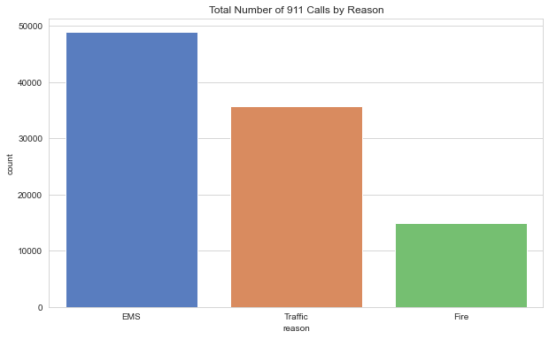

```python
plt.figure(figsize=(10,6))
sns.set_style("whitegrid")
plt.title('Total Number of 911 Calls by Reason')
sns.set_palette('muted')
reason_countgraph = sns.countplot(x = 'reason', data = df, order = df['reason'].value_counts().index)
```

```python
df['month'] = df['timeStamp'].apply(lambda x: x.month)
df['dayofweek'] = df['timeStamp'].apply(lambda x: x.weekday())
df['hour'] = df['timeStamp'].apply(lambda x: x.hour)
```

```python
df.head()
```

|  | lat | lng | desc | zip | title | timeStamp | twp | addr | reason | month | dayofweek | hour |
| --- | --- | --- | --- | --- | --- | --- | --- | --- | --- | --- | --- | --- |
| 0 | 40.297876 | -75.581294 | REINDEER CT & DEAD END; NEW HANOVER; Station ... | 19525.0 | EMS: BACK PAINS/INJURY | 2015-12-10 17:40:00 | NEW HANOVER | REINDEER CT & DEAD END | EMS | 12 | 3 | 17 |
| 1 | 40.258061 | -75.264680 | BRIAR PATH & WHITEMARSH LN; HATFIELD TOWNSHIP... | 19446.0 | EMS: DIABETIC EMERGENCY | 2015-12-10 17:40:00 | HATFIELD TOWNSHIP | BRIAR PATH & WHITEMARSH LN | EMS | 12 | 3 | 17 |
| 2 | 40.121182 | -75.351975 | HAWS AVE; NORRISTOWN; 2015-12-10 @ 14:39:21-St... | 19401.0 | Fire: GAS-ODOR/LEAK | 2015-12-10 17:40:00 | NORRISTOWN | HAWS AVE | Fire | 12 | 3 | 17 |
| 3 | 40.116153 | -75.343513 | AIRY ST & SWEDE ST; NORRISTOWN; Station 308A;... | 19401.0 | EMS: CARDIAC EMERGENCY | 2015-12-10 17:40:01 | NORRISTOWN | AIRY ST & SWEDE ST | EMS | 12 | 3 | 17 |
| 4 | 40.251492 | -75.603350 | CHERRYWOOD CT & DEAD END; LOWER POTTSGROVE; S... | NaN | EMS: DIZZINESS | 2015-12-10 17:40:01 | LOWER POTTSGROVE | CHERRYWOOD CT & DEAD END | EMS | 12 | 3 | 17 |

We see that the 'dayofweek' column is an integer from 0-6. We can map these integers to the corresponding day of the week:

```python
day_map = {0:'Monday', 1:'Tuesday', 2:'Wednesday', 3:'Thursday', 4:'Friday', 5:'Saturday', 6:'Sunday'}

# Sorted the dataframe for use in the visualization later
df_sorted = df.sort_values(by=['dayofweek']).copy()
df_sorted['dayofweek'] = df_sorted['dayofweek'].apply(lambda x: day_map[x])

df['dayofweek'] = df['dayofweek'].apply(lambda x: day_map[x])
```

```python
df.head()
```

|  | lat | lng | desc | zip | title | timeStamp | twp | addr | reason | month | dayofweek | hour |
| --- | --- | --- | --- | --- | --- | --- | --- | --- | --- | --- | --- | --- |
| 0 | 40.297876 | -75.581294 | REINDEER CT & DEAD END; NEW HANOVER; Station ... | 19525.0 | EMS: BACK PAINS/INJURY | 2015-12-10 17:40:00 | NEW HANOVER | REINDEER CT & DEAD END | EMS | 12 | Thursday | 17 |
| 1 | 40.258061 | -75.264680 | BRIAR PATH & WHITEMARSH LN; HATFIELD TOWNSHIP... | 19446.0 | EMS: DIABETIC EMERGENCY | 2015-12-10 17:40:00 | HATFIELD TOWNSHIP | BRIAR PATH & WHITEMARSH LN | EMS | 12 | Thursday | 17 |
| 2 | 40.121182 | -75.351975 | HAWS AVE; NORRISTOWN; 2015-12-10 @ 14:39:21-St... | 19401.0 | Fire: GAS-ODOR/LEAK | 2015-12-10 17:40:00 | NORRISTOWN | HAWS AVE | Fire | 12 | Thursday | 17 |
| 3 | 40.116153 | -75.343513 | AIRY ST & SWEDE ST; NORRISTOWN; Station 308A;... | 19401.0 | EMS: CARDIAC EMERGENCY | 2015-12-10 17:40:01 | NORRISTOWN | AIRY ST & SWEDE ST | EMS | 12 | Thursday | 17 |
| 4 | 40.251492 | -75.603350 | CHERRYWOOD CT & DEAD END; LOWER POTTSGROVE; S... | NaN | EMS: DIZZINESS | 2015-12-10 17:40:01 | LOWER POTTSGROVE | CHERRYWOOD CT & DEAD END | EMS | 12 | Thursday | 17 |

Looks good, we can now visualize the number of 911 calls by day:

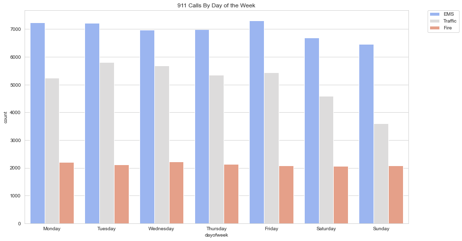

```python
plt.figure(figsize=(14,8))
sns.set_style("whitegrid")
plt.title('911 Calls By Day of the Week')
sns.countplot(x ='dayofweek', data = df_sorted, hue = 'reason', palette = 'coolwarm')
legend = plt.legend(bbox_to_anchor=(1.05, 1), loc=2, borderaxespad=0.)
```

Visualizing 911 calls by month:

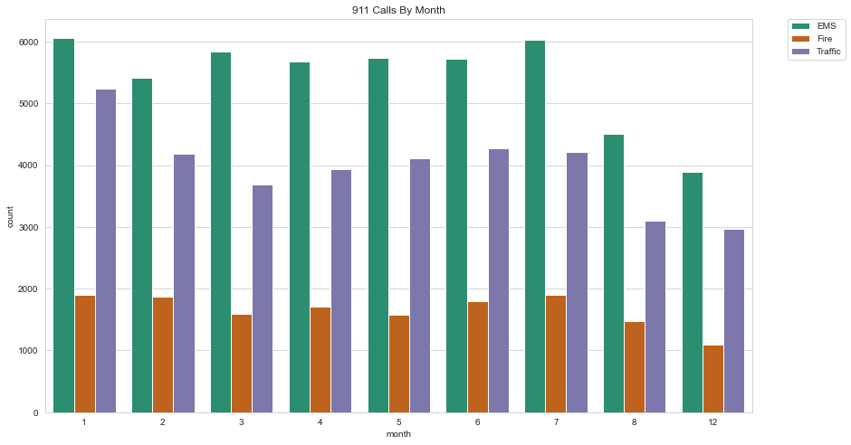

```python
plt.figure(figsize=(14,8))
sns.set_style("whitegrid")
plt.title('911 Calls By Month')
sns.countplot(x ='month', data = df, hue = 'reason', palette='Dark2')
legend = plt.legend(bbox_to_anchor=(1.05, 1), loc=2, borderaxespad=0.)
```

```python
df2 = df.groupby('month').count()
```

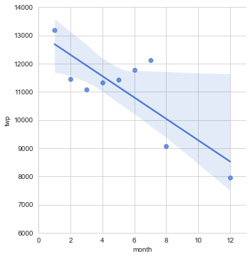

```python
plot1 = sns.lmplot(x = 'month', y='twp', data=df2.reset_index())
xlim = plot1.set(xlim=(0, 13))
ylim = plot1.set(ylim=(6000, 14000))
```

I'll now create a new column called 'date' that takes the date of 'timeStamp' column to help visualize the number of 911 calls over time overall and by reason.

```python
df['date'] = df['timeStamp'].apply(lambda x: x.date())
```

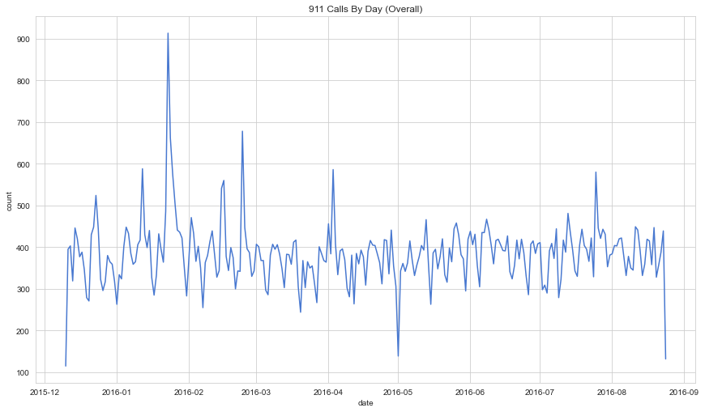

```python
plt.figure(figsize=(12,7))
sns.set_style("whitegrid")
plt.title('911 Calls By Day (Overall)')
plt.tight_layout()
line1 = sns.lineplot(x = 'date', y = 'count',
             data = pd.DataFrame(data={'date': df.date.unique(), 'count': df.groupby('date')['twp'].count()}))
```

Traffic Related 911 Calls:

```python
df_traffic = pd.DataFrame(data={'date': df.loc[df['reason'] == 'Traffic']['date'].unique(),
                                'count': df.loc[df['reason'] == 'Traffic'].groupby('date')['twp'].count()})
```

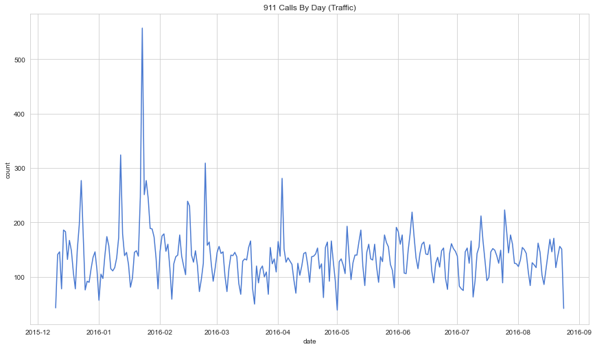

```python
plt.figure(figsize=(12,7))
sns.set_style("whitegrid")
plt.title('911 Calls By Day (Traffic)')
plt.tight_layout()
line2 = sns.lineplot(x = 'date', y = 'count', data = df_traffic)
```

Fire Related 911 Calls:

```python
df_fire = pd.DataFrame(data={'date': df.loc[df['reason'] == 'Fire']['date'].unique(),
                                'count': df.loc[df['reason'] == 'Fire'].groupby('date')['twp'].count()})
```

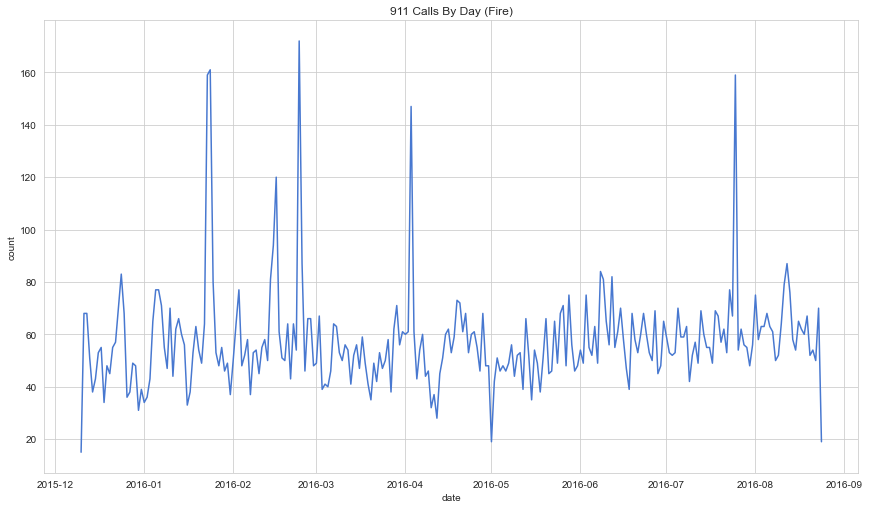

```python
plt.figure(figsize=(12,7))
sns.set_style("whitegrid")
plt.title('911 Calls By Day (Fire)')
plt.tight_layout()
line2 = sns.lineplot(x = 'date', y = 'count', data = df_fire)
```

EMS Related 911 Calls:

```python
df_ems = pd.DataFrame(data={'date': df.loc[df['reason'] == 'EMS']['date'].unique(),
                                'count': df.loc[df['reason'] == 'EMS'].groupby('date')['twp'].count()})
```

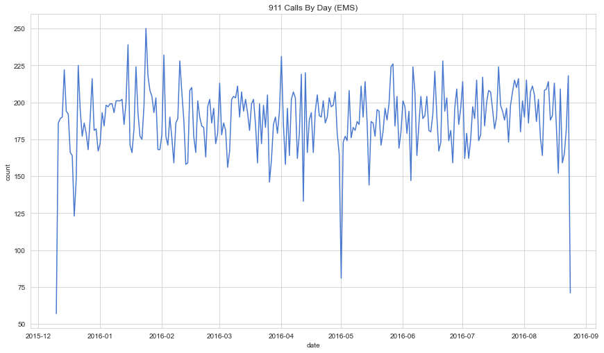

```python
plt.figure(figsize=(12,7))
sns.set_style("whitegrid")
plt.title('911 Calls By Day (EMS)')
plt.tight_layout()
line2 = sns.lineplot(x = 'date', y = 'count', data = df_ems)
```

Finally let's create a couple of heatmap displaying the frequency of the 911 calls at certain hours of the day by month and day of the week.

```python
df_hours = df.groupby(['dayofweek', 'hour'])['twp'].count().unstack(level=-1)
df_hours.head()
```

| hour dayofweek | 0 | 1 | 2 | 3 | 4 | 5 | 6 | 7 | 8 | 9 | ... | 14 | 15 | 16 | 17 | 18 | 19 | 20 | 21 | 22 | 23 |
| --- | --- | --- | --- | --- | --- | --- | --- | --- | --- | --- | --- | --- | --- | --- | --- | --- | --- | --- | --- | --- | --- |
| Friday | 275 | 235 | 191 | 175 | 201 | 194 | 372 | 598 | 742 | 752 | ... | 931 | 980 | 1039 | 980 | 819 | 696 | 667 | 558 | 514 | 474 |
| Monday | 282 | 220 | 201 | 194 | 204 | 267 | 397 | 653 | 819 | 785 | ... | 869 | 913 | 988 | 997 | 885 | 746 | 612 | 496 | 471 | 325 |
| Saturday | 373 | 301 | 263 | 260 | 224 | 231 | 257 | 391 | 459 | 640 | ... | 789 | 796 | 848 | 757 | 778 | 696 | 627 | 571 | 505 | 467 |
| Sunday | 383 | 304 | 285 | 268 | 242 | 240 | 300 | 401 | 483 | 620 | ... | 684 | 691 | 663 | 714 | 670 | 654 | 537 | 461 | 415 | 330 |
| Thursday | 278 | 202 | 233 | 159 | 182 | 203 | 362 | 570 | 777 | 828 | ... | 876 | 969 | 935 | 1011 | 810 | 698 | 617 | 553 | 424 | 354 |

5 rows × 24 columns

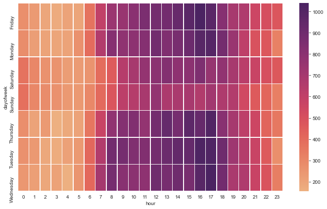

```python
plt.figure(figsize=(12,7))
heatmap1 = sns.heatmap(data=df_hours, cmap='flare', linewidths=.5)
```

```python
df_months = df.groupby(['dayofweek', 'month'])['twp'].count().unstack(level=-1)
df_months.head()
```

| month dayofweek | 1 | 2 | 3 | 4 | 5 | 6 | 7 | 8 | 12 |
| --- | --- | --- | --- | --- | --- | --- | --- | --- | --- |
| Friday | 1970 | 1581 | 1523 | 1958 | 1730 | 1649 | 2045 | 1310 | 1064 |
| Monday | 1727 | 1964 | 1533 | 1597 | 1779 | 1617 | 1692 | 1509 | 1256 |
| Saturday | 2290 | 1440 | 1264 | 1732 | 1444 | 1388 | 1695 | 1099 | 978 |
| Sunday | 1960 | 1229 | 1100 | 1488 | 1422 | 1331 | 1672 | 1021 | 907 |
| Thursday | 1584 | 1596 | 1900 | 1601 | 1590 | 2065 | 1646 | 1227 | 1265 |

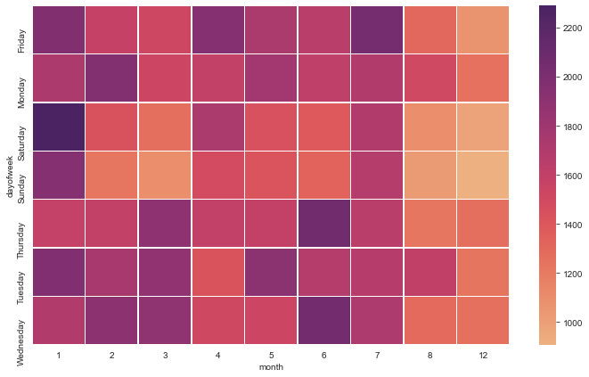

```python
plt.figure(figsize=(12,7))
heatmap2 = sns.heatmap(data=df_months, cmap='flare', linewidths=.5)
```